# Introduction

# some conditional plots makes the image more obvious

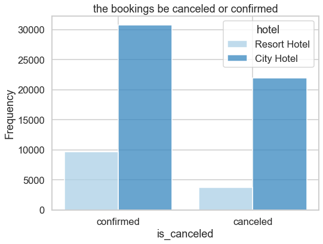

```python
plt.figure(figsize=(8,6))
sns.histplot(data=hotels,x="is_canceled", hue='hotel',bins=5,stat='frequency',multiple='dodge',element='bars',palette='Blues',shrink=.8)
plt.title('the bookings be canceled or confirmed')
```

**from the graph above we can recognize that the cancelation is real problem specially for city hotel**

# **what about the the monthes , do we have to predict more cancelations in specific monthes or seasons .. let's discover the distribution of the bookings throw the different monthes**

[figure not shown]

```python
#rordering the monthes category for better plotting
cat=['January','February','March','April','May','June','July','August','September','October','November','December']
hotels['arrival_date_month']=hotels.arrival_date_month.cat.reorder_categories(cat)
sns.catplot(data=hotels,x='arrival_date_month',hue='is_canceled',palette=palette,kind='count',height=6)
plt.xticks(rotation=45)
plt.title('cancelation in different monthes of the year')
```

**its clear that august and julie** are our top_season when we expect the double number of guests than other monthes like january and december but they are also the **top_season of the cancelation**

# what about the ADR the (the daily average rate) what or how much can we expect in the different times of the year

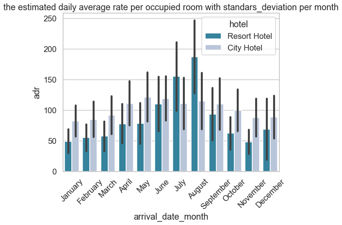

```python
plt.figure(figsize=(8,6))
plt.title('the estimated daily average rate per occupied room with standars_deviation per month')
plt.xticks(rotation=45)
sns.barplot(data=hotels,x='arrival_date_month',y='adr',hue='hotel',palette=palette,ci='sd')
```

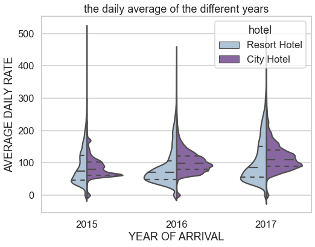

```python
#plotting boxplots for ADR in the different years
plt.figure(figsize=(8,6))
sns.violinplot(data=hotels,y='adr',x='arrival_date_year',hue='hotel',palette= 'BuPu' ,split=True,inner='quartile')
plt.ylabel('AVERAGE DAILY RATE')
plt.xlabel('YEAR OF ARRIVAL')
plt.title('the daily average of the different years')
```

# let's go on discovering the relationdhip between cancelations and other features

[figure not shown]

```python
sns.catplot(data=hotels,x='distribution_channel',hue='is_canceled',palette=palette,kind='count',height=6)
plt.title('distribution of distribution channel according cancelation')
```

> **travel agents & tour operators are have the biggest reservation ratio but also the biggest cancelation ratio while the direct bookings has the best cancelation ratio**

[figure not shown]

```python
sns.catplot(data=hotels,x='market_segment',hue='is_canceled',palette=palette,kind='count',height=6)
plt.xticks(rotation=45)
plt.title('the market segments and cancelations')
```

> - **online travel_agents are th bigest source for the reservations of our destination, while the direct_reservation has the least cancelation ratio**

[figure not shown]

```python
sns.catplot(data=hotels,x='deposit_type',hue='is_canceled',palette=palette,kind='count',height=6)
plt.title('distribution of deposit type according cancelation')
```

> - **booking with no deposit is the most common type**
> - **almost all of nun_refund deposit type reservation were canceled that was totaly unexpected**

# what is the most common type of the customers

[output not shown]

[figure not shown]

```python
g=sns.catplot(data=hotels,x='customer_type',hue='is_canceled',palette=palette,kind='count',height=6)
plt.xticks(rotation=45)
```

> - **the most common type of customers is the transient travelers that's may be why the most of bookings are from one to three nights**

# which hotel has the higher ADR

```
(0.0, 400.0)
```

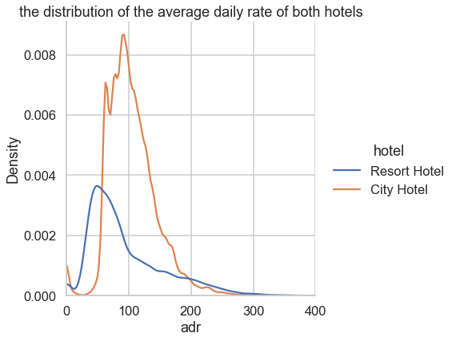

```python
#the distribution of the average daily rate of both hotels
sns.displot(x=hotels.adr,height=6,hue=hotels.hotel,kind='kde')
plt.title('the distribution of the average daily rate of both hotels')
plt.xlim(0,400)
```

```
(0.0, 500.0)
```

[figure not shown]

```python
#rordering the monthes category for better plotting
cat=['January','February','March','April','May','June','July','August','September','October','November','December']
hotels['arrival_date_month']=hotels.arrival_date_month.cat.reorder_categories(cat)
#plotting
sns.displot(x=hotels.lead_time,kind='kde', hue=hotels.is_canceled,fill=True,height=5.5)
plt.title('density distribution of the lead_time')
plt.xlim(0,500)
```

> **it's a positive skewed distribution the mean lead_time is greater than the most common lead_time**

# which country book the destination the most

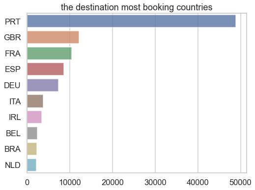

```python
countries=hotels.country.value_counts().nlargest(10)
plt.figure(figsize=(8,6))
sns.barplot(y=countries.index, x=countries.values, alpha=0.8)
plt.title('the destination most booking countries')
```

# is there a relationship between the previous cancelation of the customer and the probability that he cancel again

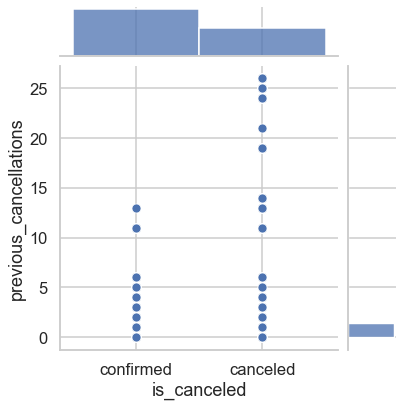

```python
sns.jointplot(data=hotels,x='is_canceled',y='previous_cancellations',height=6)
```

- **we see from this graph that the pepole how had more than 6 previous cancelations will often cancel their future reseravtion thoese pepole may be not serious with their reservations**

# what about the total nights booked and the ADR and the probability of the reservation to be canceled

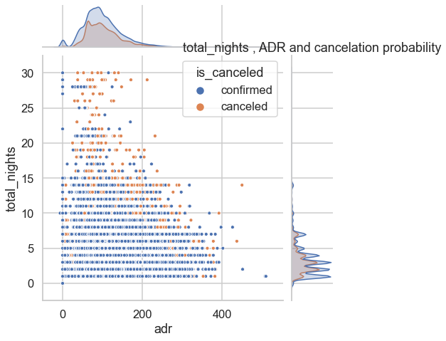

```python
sns.jointplot(data=hotels,x='adr',y='total_nights',hue='is_canceled',height=7,marker='.',s=100)
plt.title('total_nights , ADR and cancelation probability')
```

- **from the graph above we see that reservations with middle daily average rate have more chance to be canceled specially these reservations of more than 15 nights**

# let's make a simple prediction model

```python
#preparing our features for the model
hotels.reset_index()
hotels_cat=pd.get_dummies(hotels[['hotel','meal','is_repeated_guest','market_segment','customer_type','arrival_date_week_number','country','reserved_room_type']])
hotels_num= hotels[['total_nights','adults','children','previous_cancellations','lead_time']]
X=hotels_cat.join(hotels_num,how='inner')
y=hotels.is_canceled
```

```python
#fitting the model
x_train,x_test,y_train,y_test=train_test_split(X,y,test_size=.1)
clf=LogisticRegression(C=1000,solver='sag',max_iter=10000)
clf.fit(x_train,y_train)
```

```
LogisticRegression(C=1000, max_iter=10000, solver='sag')
```

```python
#model accurancy score
print('the accuracy score of the prediction model is:  ',clf.score(x_test,y_test))
```

```
the accuracy score of the prediction model is:   0.7767909509844994
```

# let's plot the the relationship between some important features

[figure not shown]

```python
g = sns.PairGrid(hotels[['is_canceled','lead_time','distribution_channel','deposit_type','previous_cancellations','adr','arrival_date_day_of_month','total_nights']])
g.map(sns.scatterplot,alpha=.5)
```

# we can see the correlations between the numeric features

```python
corr=hotels.corr()
corr.style.background_gradient(cmap='coolwarm').set_precision(2)
```

|  | lead_time | arrival_date_year | arrival_date_week_number | arrival_date_day_of_month | stays_in_weekend_nights | stays_in_week_nights | adults | children | babies | is_repeated_guest | previous_cancellations | previous_bookings_not_canceled | booking_changes | days_in_waiting_list | adr | required_car_parking_spaces | total_of_special_requests | total_nights |
| --- | --- | --- | --- | --- | --- | --- | --- | --- | --- | --- | --- | --- | --- | --- | --- | --- | --- | --- |
| lead_time | 1.00 | 0.04 | 0.13 | 0.00 | 0.09 | 0.17 | 0.13 | -0.04 | -0.02 | -0.12 | 0.09 | -0.07 | 0.00 | 0.17 | -0.07 | -0.12 | -0.10 | 0.16 |
| arrival_date_year | 0.04 | 1.00 | -0.54 | -0.00 | 0.02 | 0.03 | 0.05 | 0.06 | -0.01 | 0.01 | -0.12 | 0.03 | 0.03 | -0.06 | 0.21 | -0.01 | 0.11 | 0.03 |
| arrival_date_week_number | 0.13 | -0.54 | 1.00 | 0.07 | 0.02 | 0.02 | 0.03 | 0.01 | 0.01 | -0.03 | 0.04 | -0.02 | 0.01 | 0.02 | 0.08 | 0.00 | 0.03 | 0.02 |
| arrival_date_day_of_month | 0.00 | -0.00 | 0.07 | 1.00 | -0.02 | -0.03 | 0.00 | 0.01 | 0.00 | -0.01 | -0.03 | -0.00 | 0.01 | 0.02 | 0.03 | 0.01 | 0.00 | -0.03 |
| stays_in_weekend_nights | 0.09 | 0.02 | 0.02 | -0.02 | 1.00 | 0.48 | 0.11 | 0.05 | 0.02 | -0.09 | -0.01 | -0.04 | 0.05 | -0.05 | 0.06 | -0.02 | 0.07 | 0.75 |
| stays_in_week_nights | 0.17 | 0.03 | 0.02 | -0.03 | 0.48 | 1.00 | 0.11 | 0.05 | 0.02 | -0.10 | -0.01 | -0.05 | 0.08 | -0.00 | 0.07 | -0.02 | 0.07 | 0.94 |
| adults | 0.13 | 0.05 | 0.03 | 0.00 | 0.11 | 0.11 | 1.00 | 0.04 | 0.03 | -0.17 | -0.01 | -0.13 | -0.06 | -0.01 | 0.30 | 0.02 | 0.15 | 0.13 |
| children | -0.04 | 0.06 | 0.01 | 0.01 | 0.05 | 0.05 | 0.04 | 1.00 | 0.03 | -0.03 | -0.02 | -0.02 | 0.05 | -0.03 | 0.34 | 0.06 | 0.08 | 0.05 |
| babies | -0.02 | -0.01 | 0.01 | 0.00 | 0.02 | 0.02 | 0.03 | 0.03 | 1.00 | -0.01 | -0.01 | -0.01 | 0.09 | -0.01 | 0.03 | 0.04 | 0.11 | 0.03 |
| is_repeated_guest | -0.12 | 0.01 | -0.03 | -0.01 | -0.09 | -0.10 | -0.17 | -0.03 | -0.01 | 1.00 | 0.08 | 0.42 | 0.01 | -0.02 | -0.14 | 0.08 | 0.01 | -0.11 |
| previous_cancellations | 0.09 | -0.12 | 0.04 | -0.03 | -0.01 | -0.01 | -0.01 | -0.02 | -0.01 | 0.08 | 1.00 | 0.15 | -0.03 | 0.01 | -0.07 | -0.02 | -0.05 | -0.02 |
| previous_bookings_not_canceled | -0.07 | 0.03 | -0.02 | -0.00 | -0.04 | -0.05 | -0.13 | -0.02 | -0.01 | 0.42 | 0.15 | 1.00 | 0.01 | -0.01 | -0.08 | 0.05 | 0.04 | -0.05 |
| booking_changes | 0.00 | 0.03 | 0.01 | 0.01 | 0.05 | 0.08 | -0.06 | 0.05 | 0.09 | 0.01 | -0.03 | 0.01 | 1.00 | -0.01 | 0.02 | 0.07 | 0.05 | 0.08 |
| days_in_waiting_list | 0.17 | -0.06 | 0.02 | 0.02 | -0.05 | -0.00 | -0.01 | -0.03 | -0.01 | -0.02 | 0.01 | -0.01 | -0.01 | 1.00 | -0.04 | -0.03 | -0.08 | -0.02 |
| adr | -0.07 | 0.21 | 0.08 | 0.03 | 0.06 | 0.07 | 0.30 | 0.34 | 0.03 | -0.14 | -0.07 | -0.08 | 0.02 | -0.04 | 1.00 | 0.06 | 0.18 | 0.08 |
| required_car_parking_spaces | -0.12 | -0.01 | 0.00 | 0.01 | -0.02 | -0.02 | 0.02 | 0.06 | 0.04 | 0.08 | -0.02 | 0.05 | 0.07 | -0.03 | 0.06 | 1.00 | 0.08 | -0.03 |
| total_of_special_requests | -0.10 | 0.11 | 0.03 | 0.00 | 0.07 | 0.07 | 0.15 | 0.08 | 0.11 | 0.01 | -0.05 | 0.04 | 0.05 | -0.08 | 0.18 | 0.08 | 1.00 | 0.08 |
| total_nights | 0.16 | 0.03 | 0.02 | -0.03 | 0.75 | 0.94 | 0.13 | 0.05 | 0.03 | -0.11 | -0.02 | -0.05 | 0.08 | -0.02 | 0.08 | -0.03 | 0.08 | 1.00 |

# conclusions

# resoures

> [the site of sincedirect the dataset source](https://www.sciencedirect.com/science/article/pii/S2352340918315191)  
> [pandas library doucumentation](https://pandas.pydata.org/docs/reference/api)  
> [seaborn documentaion](https://seaborn.pydata.org/)  
> [matplotlib documentation](https://matplotlib.org/)  
> [stack overflow](https://stackoverflow.com/)